# Manipulation d’objets spatiaux en R

`sf`, `terra`, projections, opérations spatiales et cartographie

François Rousseu

2026-08-27

# Introduction

## Deux formats, un seul fichier

Ce document se compile de deux façons :

- **Site web** (document défilant avec sommaire) : `quarto render index.qmd --to html`
- **Diapos** (chaque titre `##` devient une diapo) : `quarto render index.qmd --to revealjs`

`quarto render index.qmd` produit les deux.

En mode diapos, les blocs de code longs sont défilables (`scrollable: true`).

## Prérequis

Le jeu de données original https://www.donneesquebec.ca/recherche/dataset/reseau-routier-rtss est modifié dans le script pour produire le fichier `routes.gpkg`.

```r
c("sf", "terra",           # vecteur + raster
  "geodata", "rgbif",      # données à télécharger (frontières, occurrences)
  "rmapshaper",            # simplification de polygones
  "mapview", "leaflet",    # cartes interactives
  "ggplot2", "tidyterra",  # cartographie
  "dplyr"                  # manipulation
) |> lapply(library, character.only = TRUE) |> invisible()
```

Les fichiers sont déposés et produits dans le dossier data et le chemin doit être indiqué avec la variable `datadir`.

```r
datadir <- "data"
```

## Objectif de la présentation

Introduction à la manipulation des **objets spatiaux** en R: lire, construire, projeter, transformer, interroger et cartographier des données **vectorielles** et **matricielles**.

Les deux paquets essentiels :

- [`sf`](https://r-spatial.github.io/sf) — vecteurs : points, lignes, polygones, *shapefiles*, (`.shp`), *geopackages* (`.gpkg`)
- [`terra`](https://rspatial.github.io/terra/) — données matricielles (*rasters*) (grilles régulières de pixels)

À noter que vous verrez parfois des références aux anciens paquets `sp`, `rgdal`, `rgeos` et `raster`. Ces derniers ont été entièrement remplacés par `sf` et `terra`.

## Vecteur ou raster ?

Deux grandes familles de données spatiales :

- **Vectorielles** — des géométries discrètes (points, lignes, polygones) avec des attributs. *Exemples : occurrences d’espèces, routes, limites administratives.* → `sf`
- **Matricielles (*raster*)** — une grille régulière de pixels, chaque pixel portant une valeur. *Exemples : élévation, température, couvert forestier.* → `terra`

# Données vectorielles (`sf`)

## Lire un fichier vectoriel

La lecture se fait avec `st_read()`, qui reconnaît le format d’après l’extension (`.shp`, `.gpkg`, etc.).

```r
library(sf)

roads <- st_read(file.path(datadir, "routes.gpkg"))
```

## Qu’est-ce qu’un objet `sf` ?

Un objet `sf` est essentiellement un `data.frame` auquel on a ajouté une **colonne de géométrie**.

```r
class(roads)
```

```
## [1] "sf"         "data.frame"
```

```r
head(roads)
```

```
## Simple feature collection with 6 features and 3 fields
## Geometry type: MULTILINESTRING
## Dimension:     XY
## Bounding box:  xmin: -75.94018 ymin: 45.01155 xmax: -68.20807 ymax: 48.59355
## Geodetic CRS:  WGS 84
##   num_route des_clasf_ cod_clasf_                           geom
## 1     00005  Autoroute         10 MULTILINESTRING ((-75.94018...
## 2     00010  Autoroute         10 MULTILINESTRING ((-73.55308...
## 3     00013  Autoroute         10 MULTILINESTRING ((-73.86366...
## 4     00015  Autoroute         10 MULTILINESTRING ((-74.2874 ...
## 5     00019  Autoroute         10 MULTILINESTRING ((-73.73537...
## 6     00020  Autoroute         10 MULTILINESTRING ((-74.34795...
```

## Presque un simple `data.frame`

Sans la géométrie, ce sont des attributs ordinaires.

```r
head(as.data.frame(roads)[, 1:3])
```

```
##   num_route des_clasf_ cod_clasf_
## 1     00005  Autoroute         10
## 2     00010  Autoroute         10
## 3     00013  Autoroute         10
## 4     00015  Autoroute         10
## 5     00019  Autoroute         10
## 6     00020  Autoroute         10
```

On peut donc filtrer, trier et joindre un objet `sf` comme n’importe quel `data.frame`, la géométrie suivant automatiquement.

## Visualiser la géométrie

`plot()` possède une méthode pour les objets `sf` et `st_geometry()` extrait la géométrie (sans les attributs) — essentiel pour vérifier que nos objets spatiaux correspondent à ce qui est attendu.

```r
plot(st_geometry(roads), axes = TRUE)
```

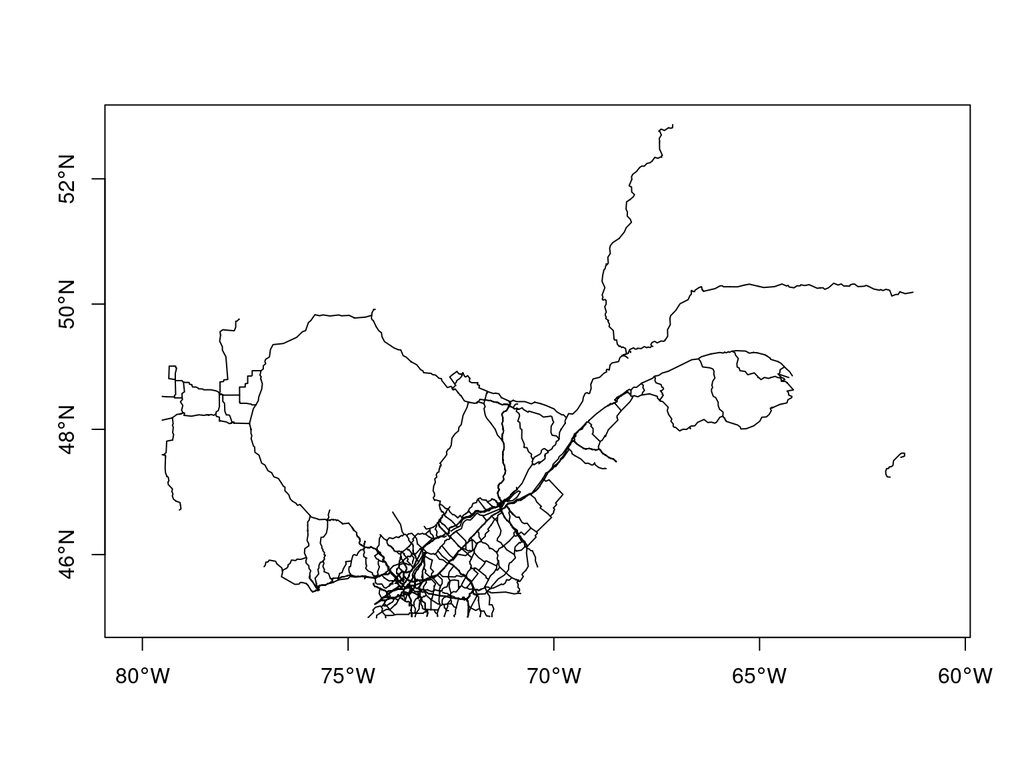

## Visualiser un attribut

On peut également utiliser une colonne particulière pour visualiser les attributs:

```r
plot(roads["des_clasf_"], axes = TRUE)
```

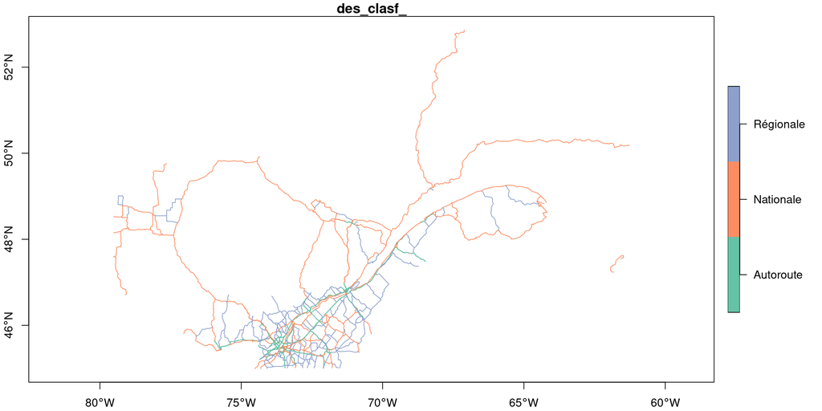

## Construire un objet `sf` à partir d’un `data.frame`

`st_as_sf()` transforme un `data.frame` en objet spatial.

```r
reseau <- read.csv("data/reseau.csv")
reseau <- st_as_sf(reseau, coords = c("lon", "lat"), crs = 4326)
head(reseau, 3)
```

```
## Simple feature collection with 3 features and 11 fields
## Geometry type: POINT
## Dimension:     XY
## Bounding box:  xmin: -72.303 ymin: 45.4599 xmax: -71.0001 ymax: 46.8088
## Geodetic CRS:  WGS 84
##   id cell_id off_station_code_id   site_code      type  opened_at notes
## 1  1     134                <NA> 135_104_H01    marais 2016-06-23  <NA>
## 2  2     134          46487218-2 135_104_F01 forestier 2016-05-20  <NA>
## 3  3     198                <NA> 148_101_F01 forestier 2016-05-17  <NA>
##                   created_at                 updated_at site_name extra
## 1 2018-11-07 13:49:59.242001 2018-11-07 13:49:59.242001      <NA>  <NA>
## 2 2018-11-07 13:49:59.581001 2018-11-07 13:49:59.581001      <NA>  <NA>
## 3 2018-11-07 13:49:59.844002 2018-11-07 13:49:59.844002      <NA>  <NA>
##                   geometry
## 1 POINT (-72.2994 46.8088)
## 2  POINT (-72.303 46.7941)
## 3 POINT (-71.0001 45.4599)
```

Le code `4326` identifie le système géographique WGS84 (lon/lat). Nous y reviendrons.

## Écrire des données

```r
st_write(roads, "roads.shp",  append = FALSE)
st_write(roads, "roads.gpkg", append = FALSE) # append = FALSE écrase un fichier déjà existant
```

Le **geopackage** (`.gpkg`) remplace de plus en plus le shapefile (`.shp`) : un seul fichier, pas de limite de longueur des noms de colonnes, possibilité d’emmagasiner plusieurs jeux de données et plusieurs types de géométries, requête SQL, etc.

## Carte interactive

Le paquet [`mapview`](https://r-spatial.github.io/mapview/) produit une carte navigable, et on superpose des couches avec `+`.

```r
library(mapview)
mapview(roads) + mapview(reseau)
```

[interactive chart not shown]

# Systèmes de coordonnées (projections)

## Qu’est-ce qu’un CRS ?

**Système de référence de coordonnées** (CRS, *Coordinate Reference System*): permet de relier des coordonnées à un endroit sur la surface du globe

- **Géographique** — coordonnées sur une sphère/ellipsoïde, en degrés (lon/lat). *Ex. : WGS84 = EPSG:4326.*
- **Projeté** — coordonnées sur un plan 2D, en mètres. *Ex. : Québec Lambert = EPSG:32198.*

On fait généralement les opérations spatiales en coordonnées projetées.

## Codes EPSG utiles

Chaque CRS porte un code **EPSG** ; voir https://epsg.io/.

[output not shown]

Les système de coordonnées projetées sont généralement adapter à un endroit particulier sur le globe et au-delà de leur zone d’application, ils peuvent introduire des déformations importantes.

## Consulter et assigner un CRS

En général, lorsqu’on crée un jeu de donnes spatial à partir d’un `data.frame`, on doit assigner un CRS.

```r
reseau <- st_as_sf(reseau, coords = c("lon", "lat"), crs = 4326)
```

`st_crs()` lit ou **assigne** un CRS. Assigner ne *transforme pas* les coordonnées : cela ne fait qu’assigner un CRS.

```r
st_crs(reseau)$epsg          # code EPSG courant
```

```
## [1] 4326
```

```r
st_is_longlat(reseau)        # est-on en en coordonées géographiques (lon/lat) ou projetées?
```

```
## [1] TRUE
```

## Transformer un CRS

`st_transform()` **reprojette** les coordonnées vers un nouveau CRS.

```r
st_bbox(reseau)                            # étendue en degrés
```

```
##      xmin      ymin      xmax      ymax
## -79.52750  45.00456 -61.47740  62.20180
```

```r
reseau_proj <- st_transform(reseau, 32198) # vers Québec Lambert
st_bbox(reseau_proj)                       # étendue en mètres
```

```
##      xmin      ymin      xmax      ymax
## -825934.0  121278.3  525890.9 2037656.3
```

`st_bbox`: Pour obtenir l’étendue un jeu de données (*bounding box*)

## Exemple — occurrences GBIF (Trille rouge)

Récupérons des occurrences du Trille rouge (*Trillium erectum*) au Québec avec [`rgbif`](https://docs.ropensci.org/rgbif/).

```r
library(rgbif)

occ <- occ_search(
  scientificName = "Trillium erectum",
  hasCoordinate = TRUE, country = "CA",
  stateProvince = "Québec", limit = 300
)

trille <- st_as_sf(occ$data,
  coords = c("decimalLongitude", "decimalLatitude"), crs = 4326)

plot(st_geometry(trille), pch = 16, cex = 0.5, axes = TRUE)
```

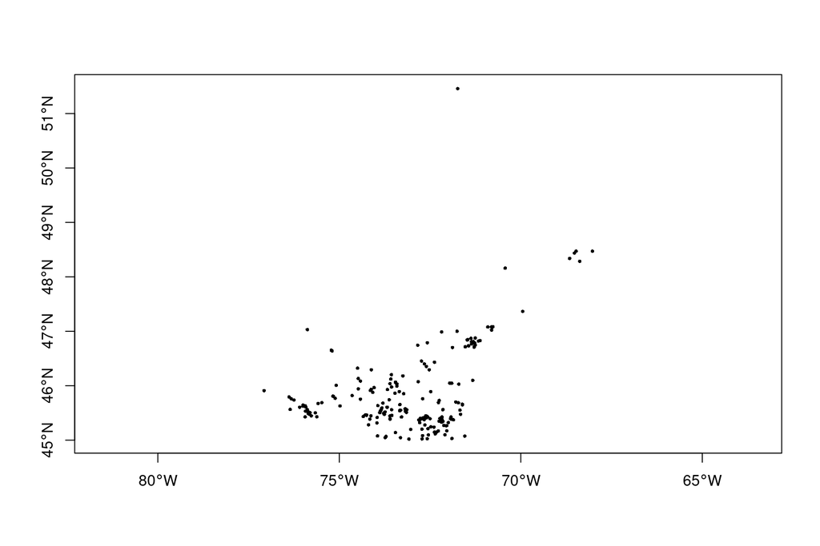

## Superposer plusieurs couches : même CRS !

Pour illustrer ou combiner plusieurs objets, ils doivent partager le même CRS. Récupérons les frontières du Québec avec [`geodata`](https://github.com/rspatial/geodata), simplifiées avec `rmapshaper::ms_simplify()`.

```r
library(geodata)
library(rmapshaper)

quebec <- gadm(country = "CAN", level = 1, path = tempdir()) |>
  st_as_sf() |>                     # on convertit en objet sf
  filter(NAME_1 == "Québec") |>     # on garde le Québec
  ms_simplify(keep = 0.01)          # conserve 1 % des sommets, topologie préservée


# on ramène le Canada dans le CRS des occurrences avant de superposer
plot(st_geometry(st_transform(quebec, st_crs(trille))), axes = TRUE)
plot(st_geometry(trille), pch = 16, cex = 0.4, col = "forestgreen", add = TRUE)
```

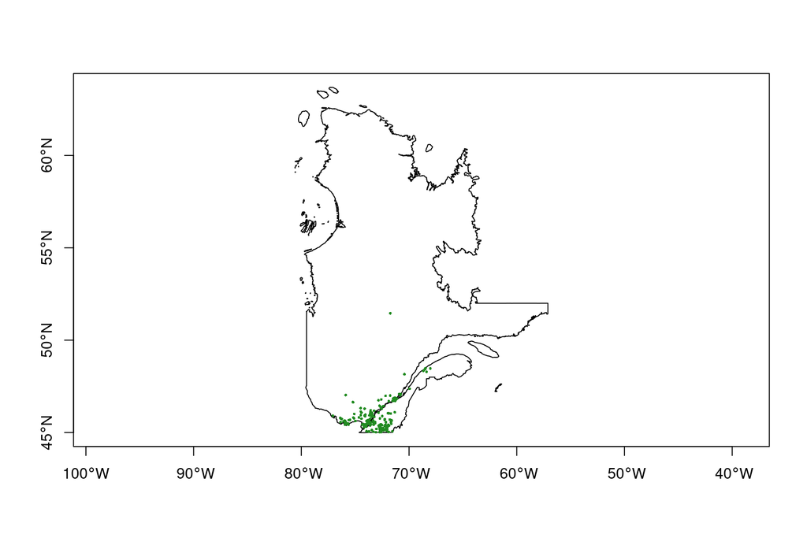

# Opérations spatiales

## Préparer les données

La plupart des opérations spatiales nécessitent un CRS **projeté**.

```r
trille <- st_transform(trille, 32198)
quebec <- st_transform(quebec, 32198)
st_is_longlat(trille)
```

```
## [1] FALSE
```

## Intersection — quels points tombent dans un polygone ?

Définissons une **zone d’étude** (un rectangle) et conservons les occurrences qui s’y trouvent.

```r
zone <- st_bbox(c(xmin = -77, xmax = -74, ymin = 45.3, ymax = 46.5), crs = 4326) |>
  st_as_sfc() |>
  st_transform(32198)

dedans <- lengths(st_intersects(trille, zone)) > 0

plot(st_geometry(zone), axes = TRUE, border = "grey40")
plot(st_geometry(trille[!dedans, ]), pch = 16, col = "blue", add = TRUE)
plot(st_geometry(trille[ dedans, ]), pch = 16, col = "red",  add = TRUE)
```

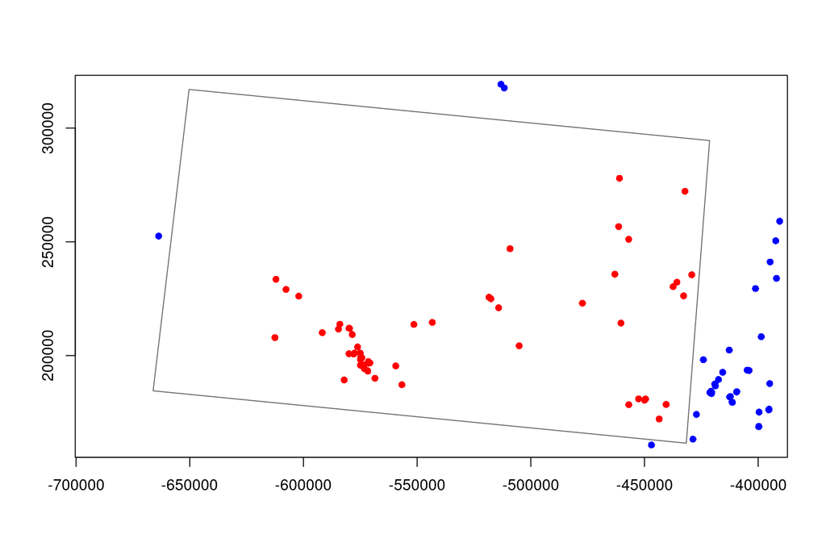

## Version compacte

Indexer un objet `sf` par un autre ne conserve que les géométries qui l’intersectent — plus concis que `st_intersects()`.

```r
trille_zone <- trille[zone, ]
nrow(trille_zone)
```

```
## [1] 61
```

## Opérations sur des points

Quelques transformations courantes (valables aussi sur lignes et polygones).

```r
x <- trille_zone
par(mfrow = c(2, 3), mar = c(0, 2, 1.5, 2))

centro <- st_union(x) |> st_centroid()
plot(st_geometry(x), main = "st_centroid(x)"); plot(centro, col = "red", pch = 16, cex = 2, add = TRUE)

conv <- st_union(x) |> st_convex_hull()
plot(st_geometry(x), main = "st_convex_hull(x)"); plot(conv, border = "red", add = TRUE)

conc <- st_union(x) |> st_concave_hull(ratio = 0.25)
plot(st_geometry(x), main = "st_concave_hull(x)"); plot(conc, border = "red", add = TRUE)

buf1 <- st_buffer(x, dist = 10000)
plot(st_geometry(x), main = "st_buffer(x) (chaque point)"); plot(st_geometry(buf1), border = "red", add = TRUE)

bufA <- st_union(x) |> st_buffer(dist = 10000)
plot(st_geometry(x), main = "st_buffer(x) (union)"); plot(bufA, border = "red", add = TRUE)

plot(st_geometry(x), main = "st_as_sfc(st_bbox(x))"); plot(st_geometry(st_as_sfc(st_bbox(x))), border = "red", add = TRUE)
```

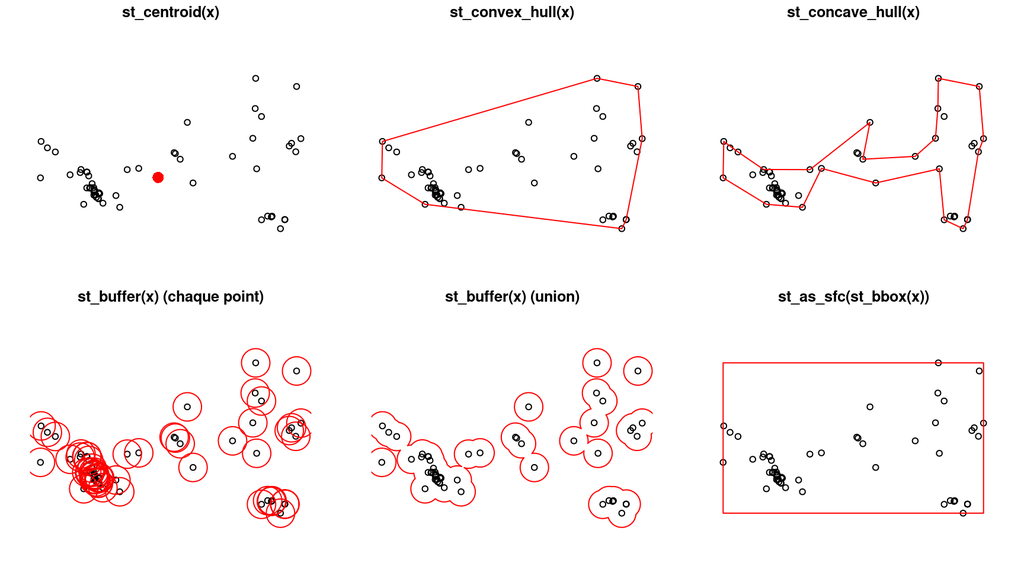

## Le rôle de `st_union()`

`st_union()` permet de **fusionner** les géométries.

```r
length(st_geometry(x))              # plusieurs points
```

```
## [1] 61
```

```r
length(st_geometry(st_union(x)))    # un seul MULTIPOINT
```

```
## [1] 1
```

## Opérations entre polygones

Construisons deux zones tampons, puis appliquons qq opérations standards.

```r
a <- st_buffer(x[10, ], dist = 50000)
b <- st_buffer(x[25, ], dist = 50000)

op <- c("st_intersection", "st_difference", "st_sym_difference", "st_union")
lims <- st_bbox(st_union(a, b))
par(mfrow = c(2, 2), mar = c(0, 0, 2, 0))

for (f in op) {
  plot(st_geometry(a), main = f, xlim = lims[c(1, 3)], ylim = lims[c(2, 4)])
  plot(st_geometry(b), add = TRUE)
  plot(st_geometry(get(f)(a, b)), col = "forestgreen", add = TRUE)
}
```

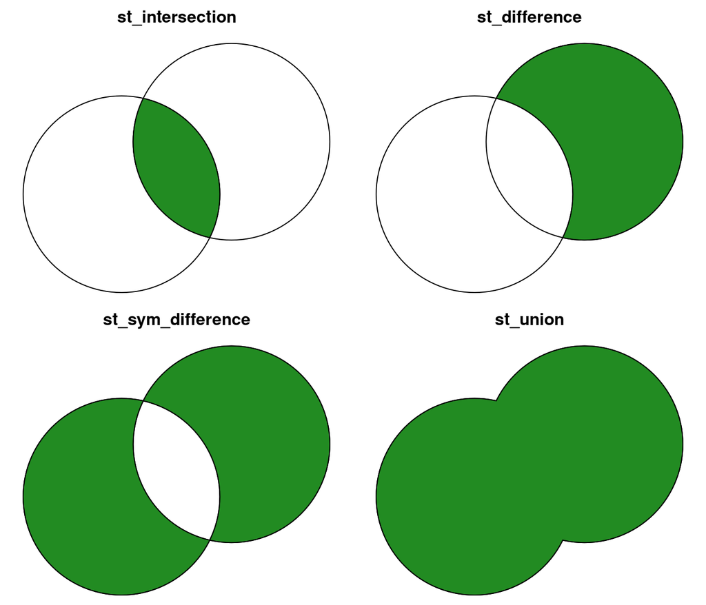

## Mesurer distances et surfaces

En CRS projeté, les résultats sont généralement en mètres (et m²).

```r
d <- st_distance(x[1:5, ], st_union(x) |> st_centroid())
round(as.numeric(d) / 1000, 1)            # distances au centroïde, en km
```

```
## [1] 45.7 43.0 46.9 20.1 94.0
```

```r
st_area(a) |> as.numeric() |> (\(v) round(v / 1e6, 1))()  # surface en km²
```

```
## [1] 7850.4
```

## Exemple — longueur de routes pour chaque zone tampon

On enchaîne plusieurs opérations : choisir des points aléatoires, transormer en zones tampons, puis mesurer la longueur de routes dans chacun.

```r
set.seed(12345)

roads <- st_transform(roads, 32198)

n <- 10

buffers <- st_union(roads) |>
  st_convex_hull() |>
  st_sample(n) |>
  st_buffer(dist = 100000)

sections <- st_intersection(buffers, roads)   # portions de routes dans les tampons
liens <- st_intersects(buffers, sections)


par(mar=c(0, 0, 0, 0))
plot(buffers, border = "black", col = adjustcolor("grey", 0.2))
plot(st_geometry(roads), col = "grey70", add = TRUE)

longueurs <- sapply(liens, \(i){
  plot(st_geometry(sections[i]), col = "red", add = TRUE)
  sum(st_length(sections[i]))
})

text(st_coordinates(st_centroid(st_sfc(buffers))),
     labels = round(as.numeric(longueurs) / 1000, 1), cex = 2)
```

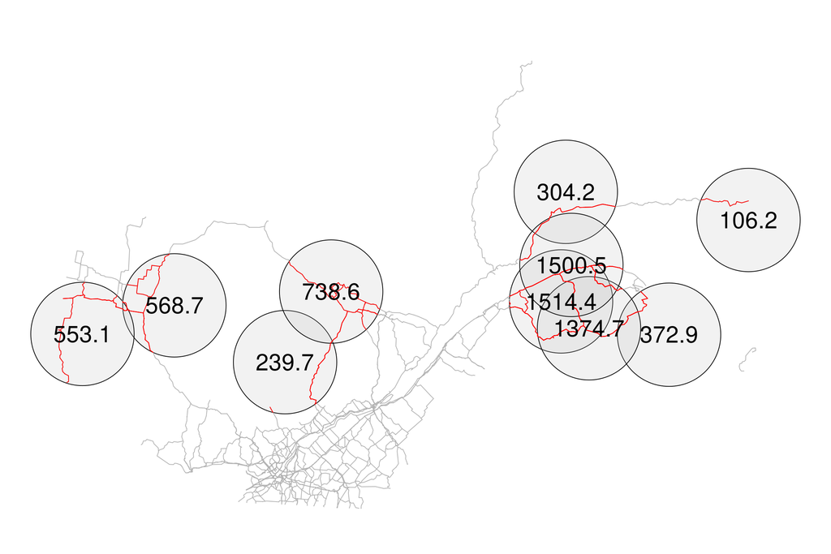

# Données matricielles (`terra`)

## Qu’est-ce qu’un raster ?

Une grille régulière de pixels, chacune portant une valeur.

`rast()` permet de créer un raster de toutes pièces.

```r
library(terra)

r <- rast(nrow = 120, ncol = 120,
          ext = ext(-80, -60, 45, 62), crs = "EPSG:4326")
values(r) <- runif(ncell(r))
r
```

```
## class       : SpatRaster
## size        : 120, 120, 1  (nrow, ncol, nlyr)
## resolution  : 0.1666667, 0.1416667  (x, y)
## extent      : -80, -60, 45, 62  (xmin, xmax, ymin, ymax)
## coord. ref. : lon/lat WGS 84 (EPSG:4326)
## source(s)   : memory
## name        :    lyr.1
## min value   : 0.000052
## max value   : 0.999967
```

```r
plot(r)
```

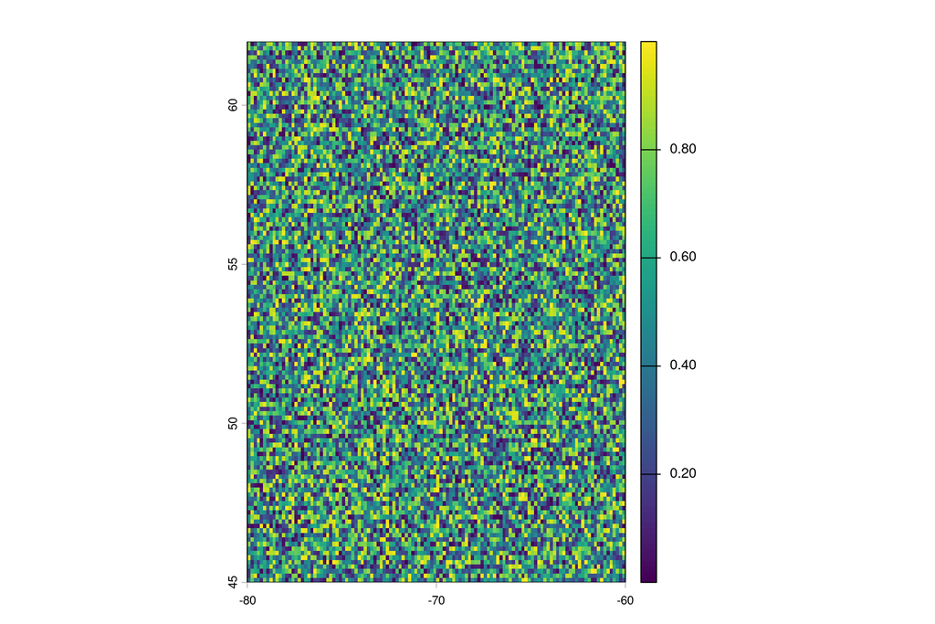

## Lire et écrire

`rast()` permet de lire un raster (le format GeoTIFF `.tif` est le plus commun)

`writeRaster()` permet d’écrire sur le disque

```r
writeRaster(r, "rast.tif", overwrite = TRUE)
r2 <- rast("rast.tif")
```

## Charger de vraies données — élévation du Canada

`geodata::elevation_30s()` télécharge un modèle d’élévation.

```r
elev <- elevation_30s(country = "CAN", path = tempdir(), mask = TRUE)
elev
```

[output not shown]

```r
plot(elev)
```

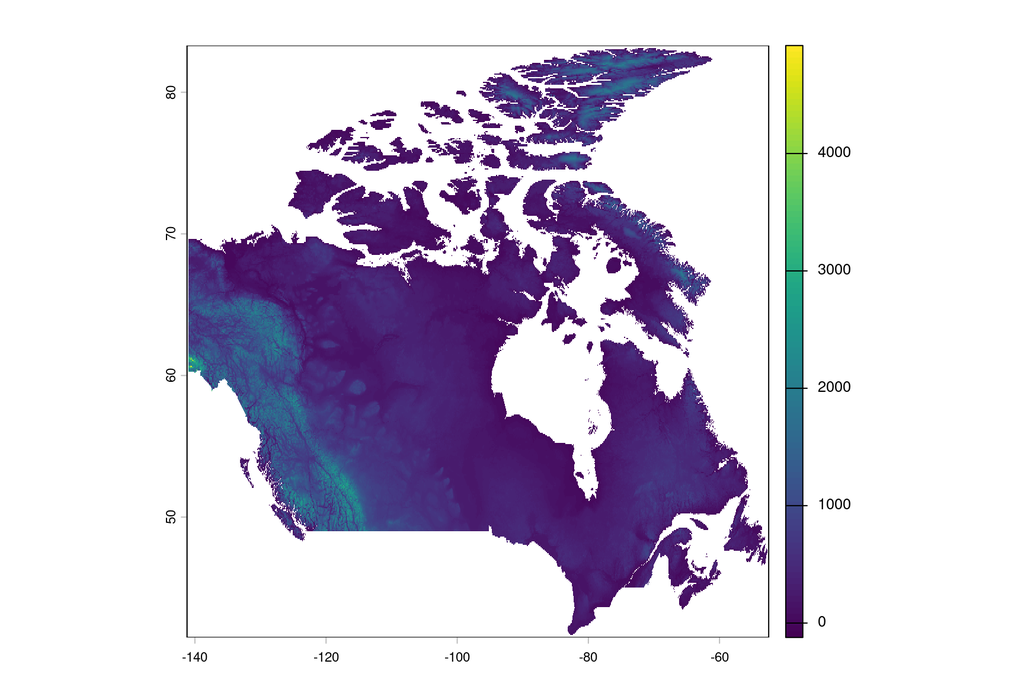

## Agréger

`aggregate()` réduit la résolution par un facteur donné (utile pour alléger l’affichage ou le calcul).

```r
ncell(elev)
```

```
## [1] 53390304
```

```r
elev10 <- aggregate(elev, fact = 10, fun = "mean")
ncell(elev10)
```

```
## [1] 534630
```

## Découper et masquer

`crop()` restreint l’étendue d’un raster

`mask()` permet de restreindre à une étendue particulière

```r
elev_qc <- crop(elev, st_transform(quebec, st_crs(elev)), mask = TRUE)
plot(elev_qc)
plot(st_geometry(st_transform(quebec, st_crs(elev))), add = TRUE)
```

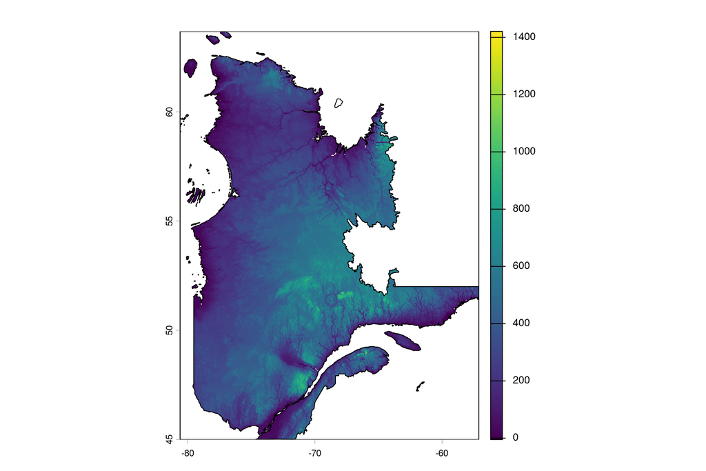

Remarquez qu’on projette au préalable le polygone du Québec dans le CRS du raster. Aussi, les objets `sf` et `terra` sont généralement interopérables.

## Extraire des valeurs sous des points

`extract()` récupère la valeur du raster à l’emplacement de chaque géométrie. Le vecteur est ramené au CRS du raster (règle : on transforme le vecteur).

```r
pts_elev <- st_transform(trille_zone, crs(elev))
vals <- extract(elev, pts_elev)
head(vals)
```

```
##   ID CAN_elv_msk
## 1  1         241
## 2  2         133
## 3  3         251
## 4  4         181
## 5  5          39
## 6  6          39
```

```r
hist(vals[, 2], main = "", xlab = "Élévation (m)")
```

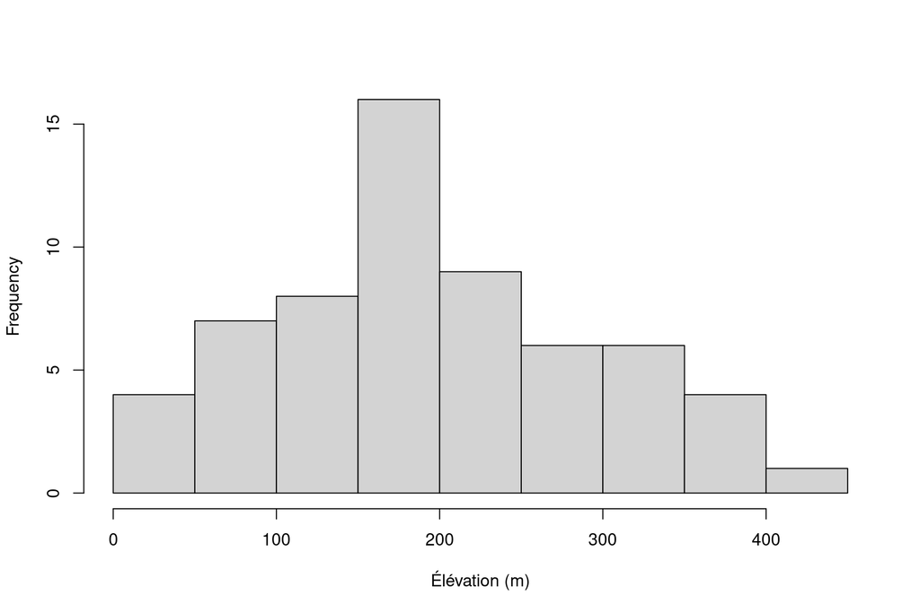

## Rasteriser des points

`rasterize()` convertit des géométries en raster. Ici, chaque pixel compte le nombre d’occurrences qu’il contient.

```r
grille <- rast(resolution = 20000, ext = ext(trille), crs = crs(trille))
compte <- rasterize(trille, grille, fun = "length", background = 0)
compte[compte == 0] <- NA
plot(compte)
plot(st_geometry(st_transform(quebec, st_crs(trille))), add = TRUE)
```

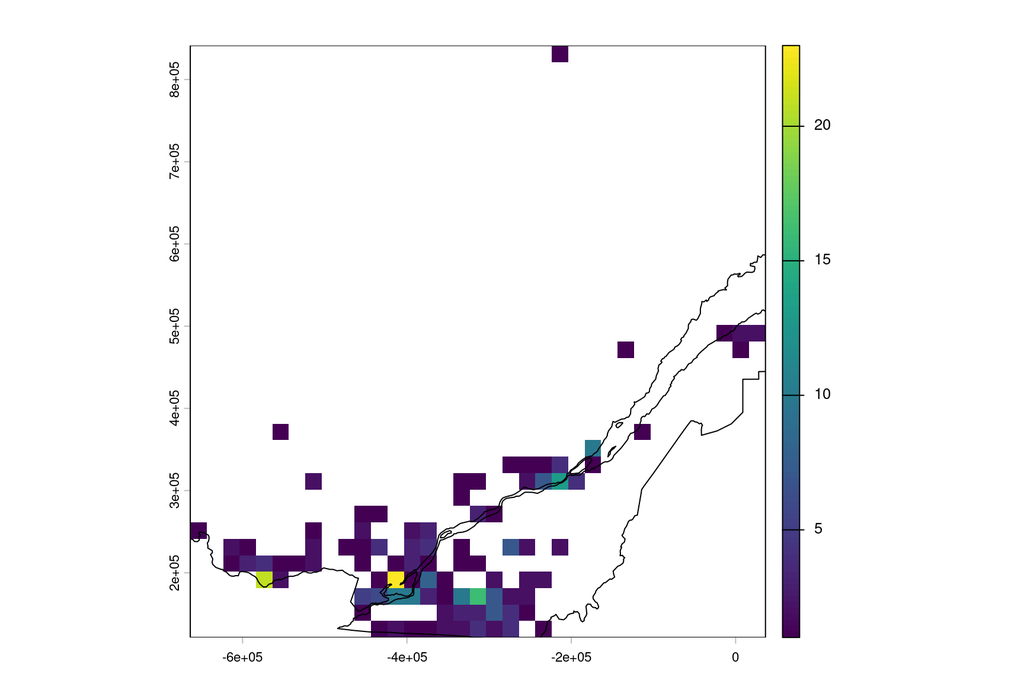

## Reclasser

`classify()` regroupe des valeurs continues en classes.

```r
seuils <- cbind(c(-100, 0, 100, 200, 300, 500, 750, 1000), c(0, 100, 200, 300, 500, 750, 1000, 1500), 1:8)
elev_cl <- classify(elev_qc, seuils)
lvls <- data.frame(
  value = 1:8,
  category = paste(c(-100, 0, 100, 200, 300, 500, 750, 1000), c(0, 100, 200, 300, 500, 750, 1000, 1500), sep = " - ")
)
levels(elev_cl) <- lvls
plot(elev_cl, col = rev(terrain.colors(8)))
```

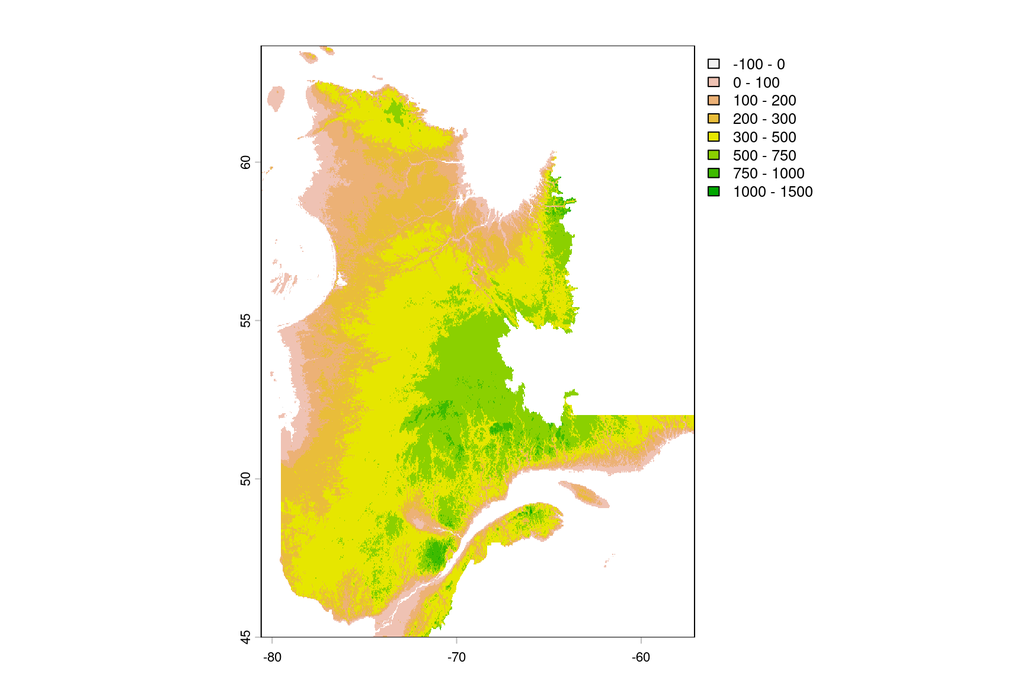

## Attention — reprojeter un raster est destructeur

Chaque reprojection d’un raster **rééchantillonne** les pixels : les valeurs d’origine sont recalculées et perdues.

> **Règle d’or : il est préférable de transformer le CRS des vecteurs pour l’adapter au raster, jamais l’inverse.**

# Cartographie

## `ggplot2` + `tidyterra`

Pour des belles cartes: `geom_spatraster()` et `geom_sf()` peuvent se combiner

```r
library(ggplot2)
library(tidyterra)

ggplot() +
  geom_spatraster(data = elev_qc) +
  geom_sf(data = st_transform(trille, 4326),
          colour = "blue", size = 0.6, alpha = 0.7) +
  scale_fill_hypso_c(na.value = NA) +
  coord_sf(expand = FALSE) +
  labs(fill = "Élévation (m)") +
  theme_light()
```

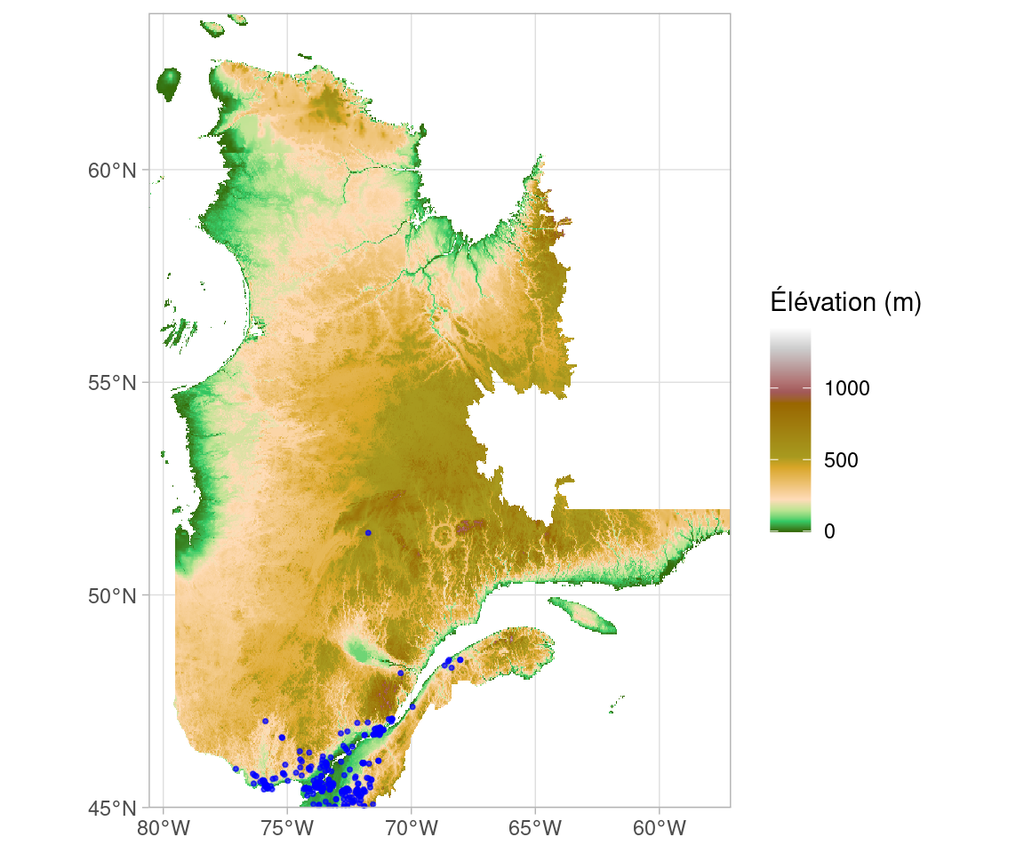

## `mapview` — exploration rapide

Idéal pour inspecter interactivement pendant l’analyse

```r
mapview(quebec, alpha.regions = 0.1) +
  mapview(st_transform(trille, 4326), cex = 3, col.regions = "orange")
```

[interactive chart not shown]

## `leaflet` — cartes interactives sur mesure

Un peu plus complexe que `mapview`, mais plus de contrôle total. `leaflet` attend du lon/lat (EPSG:4326).

```r
library(leaflet)

leaflet(st_transform(trille, 4326)) |>
  addTiles() |>
  addCircleMarkers(radius = 4, color = "orange", stroke = FALSE, fillOpacity = 0.7)
```

[output not shown]

## Pour aller plus loin

- rspatial.org
- [Geocomputation with R](https://r.geocompx.org/)
- [Spatial Data Science (`sf`/`stars`)](https://r-spatial.org/book/)
- [`tmap`](https://r-tmap.github.io/tmap/) — pour la cartographie
- [`stars`](https://r-spatial.github.io/stars/) — cubes de données spatio-temporelles (non couvert ici).